# Como ejecutar Notebook de Jupyter

### 1 - verificar los entornos(env) que hemos creado

Ejecutamos en terminal el siguiente comando

##### comando 1 -> conda env list

Muestra los entornos(env) creados y con un asterisco(*) nos indica cual es el entornos(env) activo

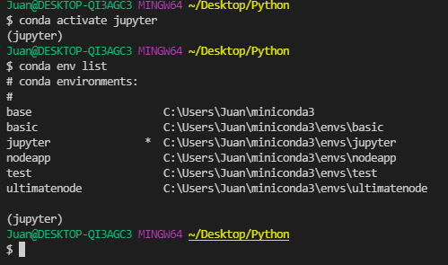

Si no hemos creado el env donde vamos a trabajar entonces damos el siguiente paso

### 2 - Crear un entornos(env)

##### comando 2 -> conda create -n jupyter

Nos va a preguntar si queremos proceder a crear el env y le decimos q si (y). Despues verificamos de nuevo si se creo el env con el comando 1

##### comando 1 -> conda env list

Si ya esta creado, procedemos a activar el nuevo env que creamos en el paso 3

### 3 - Activar un entorno(env)

Se activa con el siguiente comando, en este caso jupyter es el nombre del env

##### comando 3 -> conda activate jupyter

puede que me diga que no esta activado el shell en conda entonces le damos el comando 4

##### comando 4 -> conda init bash

verificamos que este activo con el comando 1 y con el asterisco indicar que estamos en el env deseado. Verificamos si esta instalado el notebook con el comando 5

##### comando 5 -> conda list

si no hemos instalado notebook vamos al paso 4

### 4 - Instalar Notebook de JupyterLab en env Jupyter

instalamos con el comando 6, en este caso se instala desde la libreria de conda-forge

##### comando 6 -> conda install -c conda-forge notebook

Me preguntara si deseo instalar toda la lista de paquetes a lo cual damos si(y)

Verificamos que si se instalo el notebook con el comando 7

##### comando 7 -> conda list

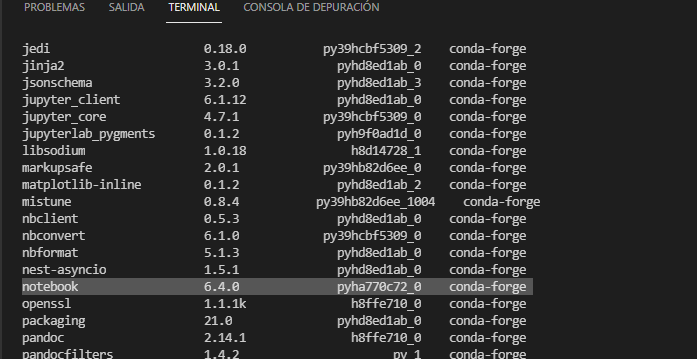

Despues de esto nos ubicamos sobre la ruta que deseamos trabajar y ejecutamos el comando 8

##### comando 8 -> jupyter notebook

# Hola mundo con Python

```python
print("Hola python desde jupyter")
```

```
Hola python desde jupyter
```

```python
print("Aca empieza mi codigo--------------------------------------")
#asi se crea una variable numerica
numero = 1
#asi se crea una variable tipo string
nombre = "Juan"
#asi se imprime un texto con una variable
print("Hola "+nombre)
#asi se imprime en consola o en terminal
print(numero)
#asi se hace un incremento de una variable
numero = numero + 1
print(numero)
print("Aca termina mi codigo--------------------------------------")
```

```
Aca empieza mi codigo--------------------------------------
Hola Juan
1
2
Aca termina mi codigo--------------------------------------
```